# R Notebook

# Installing the nessasary libraries!

Tidyverse, Readr, Here, and Janitor (has simple little tools for examining and cleaning dirty data)

```r
library(tidyverse)
library(readr)
library(here)
library(janitor)
```

# importing the dataset for the qPCR exel files

I used the following code but n_max function did the same as the following

mixprime$drop <- seq(1, 64, by=1) mixprime <- mixprime[!(mixprime$drop== c(61:64)),] mixprime <- mixprime %>% select (-c(drop))

```r
mixprime <- read_delim("Data/24 09 2021 mix primer.txt",
    "\t", escape_double = FALSE, trim_ws = TRUE, skip = 10, n_max = 60)
```

```
* `` -> ...34
```

```r
mixprime <- janitor::remove_empty(mixprime)
```

```
value for "which" not specified, defaulting to c("rows", "cols")
```

```r
mixprime$Ct <- as.numeric(mixprime$Ct, digits = 4, is.numeric = TRUE)
mixprime <- rename(mixprime,  TmValue = `Tm Value`)
mixprime
```

| Well | Sample Name | Detector Name | Reporter | Task | Ct | TmValue | Tm Type | Ct Type | Baseline Type | Threshold Type | Threshold |
| --- | --- | --- | --- | --- | --- | --- | --- | --- | --- | --- | --- |
| 49 | C1 | SYBR | SYBR | Unknown | 23.28215 | 85.7 | Auto Tm | Automatic Ct | Automatic | Automatic | 0.1239455 |
| 50 | C2 | SYBR | SYBR | Unknown | 21.27425 | 92.0 | Auto Tm | Automatic Ct | Automatic | Automatic | 0.1239455 |
| 51 | C3 | SYBR | SYBR | Unknown | 25.43309 | 87.0 | Auto Tm | Automatic Ct | Automatic | Automatic | 0.1239455 |
| 52 | C4 | SYBR | SYBR | Unknown | 22.86654 | 86.8 | Auto Tm | Automatic Ct | Automatic | Automatic | 0.1239455 |
| 53 | C5 | SYBR | SYBR | Unknown | 22.46653 | 81.4 | Auto Tm | Automatic Ct | Automatic | Automatic | 0.1239455 |
| 55 | C7 | SYBR | SYBR | Unknown | 23.54245 | 85.9 | Auto Tm | Automatic Ct | Automatic | Automatic | 0.1239455 |
| 56 | C8 | SYBR | SYBR | Unknown | 23.57744 | 90.0 | Auto Tm | Automatic Ct | Automatic | Automatic | 0.1239455 |
| 57 | C9 | SYBR | SYBR | Unknown | 25.81616 | 85.6 | Auto Tm | Automatic Ct | Automatic | Automatic | 0.1239455 |
| 58 | C10 | SYBR | SYBR | Unknown | 22.95243 | 87.0 | Auto Tm | Automatic Ct | Automatic | Automatic | 0.1239455 |
| 59 | C11 | SYBR | SYBR | Unknown | 22.36736 | 81.6 | Auto Tm | Automatic Ct | Automatic | Automatic | 0.1239455 |

[output cut: 50 more lines]

hexamers$drop <- seq(1, 64, by=1) hexamers <- hexamers[!(hexamers$drop== c(61:64)),] hexamers <- hexamers %>% select (-c(drop, NAW, EAF))

```r
hexamers <- read_delim("Data/24 09 2021 hexamers.txt",
    "\t", escape_double = FALSE, trim_ws = TRUE, skip = 10, n_max = 60)
```

```
* `` -> ...34
```

```r
hexamers <- janitor::remove_empty(hexamers)
```

```
value for "which" not specified, defaulting to c("rows", "cols")
```

```r
hexamers <- hexamers %>% select (-c( NAW, EAF))
hexamers <- rename(hexamers,  TmValue = `Tm Value`)
hexamers
```

| Well | Sample Name | Detector Name | Reporter | Task | Ct | TmValue | Tm Type | Ct Type | Baseline Type | Threshold Type | Threshold |
| --- | --- | --- | --- | --- | --- | --- | --- | --- | --- | --- | --- |
| 49 | C1 | SYBR | SYBR | Unknown | 23.015432 | 85.5 | Auto Tm | Automatic Ct | Automatic | Automatic | 0.06356634 |
| 50 | C2 | SYBR | SYBR | Unknown | Undetermined | 93.2 | Auto Tm | Automatic Ct | Automatic | Automatic | 0.06356634 |
| 51 | C3 | SYBR | SYBR | Unknown | 22.0 | 93.2 | Auto Tm | Automatic Ct | Automatic | Automatic | 0.06356634 |
| 52 | C4 | SYBR | SYBR | Unknown | 21.38899 | 89.0 | Auto Tm | Automatic Ct | Automatic | Automatic | 0.06356634 |
| 53 | C5 | SYBR | SYBR | Unknown | 23.680353 | 81.4 | Auto Tm | Automatic Ct | Automatic | Automatic | 0.06356634 |
| 55 | C7 | SYBR | SYBR | Unknown | 23.086323 | 85.7 | Auto Tm | Automatic Ct | Automatic | Automatic | 0.06356634 |
| 56 | C8 | SYBR | SYBR | Unknown | 25.18489 | 89.8 | Auto Tm | Automatic Ct | Automatic | Automatic | 0.06356634 |
| 57 | C9 | SYBR | SYBR | Unknown | 21.387346 | 85.4 | Auto Tm | Automatic Ct | Automatic | Automatic | 0.06356634 |
| 58 | C10 | SYBR | SYBR | Unknown | 21.77394 | 86.8 | Auto Tm | Automatic Ct | Automatic | Automatic | 0.06356634 |
| 59 | C11 | SYBR | SYBR | Unknown | 23.531824 | 81.4 | Auto Tm | Automatic Ct | Automatic | Automatic | 0.06356634 |

[output cut: 50 more lines]

```r
hexamers$Ct <- as.numeric(hexamers$Ct, digits = 4, is.numeric = TRUE)
```

```r
hexamers <- mutate(hexamers, SamP = `Sample Name` )
hexamers <- rename(hexamers, Strain = `Sample Name` )

hexamers <- hexamers %>% mutate(Strain = case_when(
Strain == "C1" ~ "Lnt2_WT_df1", Strain == "D1" ~ "Lnt2_WT_df1",
Strain == "E1" ~ "Lnt2_WT_df1", Strain == "C7" ~ "Lnt2_WT_df2",
Strain == "D7" ~ "Lnt2_WT_df2", Strain == "E7" ~ "Lnt2_WT_df2",

Strain == "C2" ~ "Lnt_WT_df1", Strain == "D2" ~ "Lnt_WT_df1",
Strain == "E2" ~ "Lnt_WT_df1", Strain == "C8" ~ "Lnt_WT_df2",
Strain == "D8" ~ "Lnt_WT_df2", Strain == "E8" ~ "Lnt_WT_df2",

Strain == "C3" ~ "ybeY_WT_df1", Strain == "D3" ~ "ybeY_WT_df1",
Strain == "E3" ~ "ybeY_WT_df1", Strain == "C9" ~ "ybeY_WT_df2",
Strain == "D9" ~ "ybeY_WT_df2", Strain == "E9" ~ "ybeY_WT_df2",

Strain == "C4" ~ "ybeZ_WT_df1", Strain == "D4" ~ "ybeZ_WT_df1",
Strain == "E4" ~ "ybeZ_WT_df1", Strain == "C10" ~ "ybeZ_WT_df2",
Strain == "D10" ~ "ybeZ_WT_df2", Strain == "E10" ~ "ybeZ_WT_df2",

Strain == "C5" ~ "ybeZY_WT_df1", Strain == "D5" ~ "ybeZY_WT_df1",
Strain == "E5" ~ "ybeZY_WT_df1", Strain == "C11" ~ "ybeZY_WT_df2",
Strain == "D11" ~ "ybeZY_WT_df2", Strain == "E11" ~ "ybeZY_WT_df2",

Strain == "C13" ~ "Lnt2_X_df1", Strain == "D13" ~ "Lnt2_X_df1",
Strain == "E13" ~ "Lnt2_X_df1", Strain == "C19" ~ "Lnt2_X_df2",
Strain == "D19" ~ "Lnt2_X_df2", Strain == "E19" ~ "Lnt2_X_df2",

Strain == "C14" ~ "Lnt_X_df1", Strain == "D14" ~ "Lnt_X_df1",
Strain == "E14" ~ "Lnt_X_df1", Strain == "C20" ~ "Lnt_X_df2",
Strain == "D20" ~ "Lnt_X_df2", Strain == "E20" ~ "Lnt_X_df2",

Strain == "C15" ~ "ybeY_X_df1", Strain == "D15" ~ "ybeY_X_df1",
Strain == "E15" ~ "ybeY_X_df1", Strain == "C21" ~ "ybeY_X_df2",
Strain == "D21" ~ "ybeY_X_df2", Strain == "E21" ~ "ybeY_X_df2",

Strain == "C16" ~ "ybeZ_X_df1", Strain == "D16" ~ "ybeZ_X_df1",
Strain == "E16" ~ "ybeZ_X_df1", Strain == "C22" ~ "ybeZ_X_df2",
Strain == "D22" ~ "ybeZ_X_df2", Strain == "E22" ~ "ybeZ_X_df2",

Strain == "C17" ~ "ybeZY_X_df1", Strain == "D17" ~ "ybeZY_X_df1",
Strain == "E17" ~ "ybeZY_X_df1", Strain == "C23" ~ "ybeZY_X_df2",
Strain == "D23" ~ "ybeZY_X_df2", Strain == "E23" ~ "ybeZY_X_df2"
))
```

filter(hexamers, !is.na(Strain)) hexamers <- hexamers %>% drop_na(Strain) %>% group_by(SamP)

# unite function

Convenience function to paste together multiple columns into one.

```r
hexamers <- hexamers %>% mutate( Gene = case_when(Strain %in% c("Lnt2_WT_df1", "Lnt2_WT_df2", "Lnt_WT_df1", "Lnt_WT_df2", "Lnt2_X_df1", "Lnt2_X_df2", "Lnt_X_df1", "Lnt_X_df2") ~ "lnt", Strain %in% c("ybeY_WT_df1", "ybeY_WT_df2", "ybeY_X_df1", "ybeY_X_df2") ~ "ybeY", Strain %in% c("ybeZ_WT_df1", "ybeZ_WT_df2", "ybeZ_X_df1", "ybeZ_X_df2") ~ "ybeZ", Strain %in% c("ybeZY_WT_df1", "ybeZY_WT_df2", "ybeZY_X_df1", "ybeZY_X_df2") ~ "ybeZY"
                   ),

Bacteria = case_when(Strain %in% c("Lnt2_WT_df1", "Lnt2_WT_df2", "Lnt_WT_df1", "Lnt_WT_df2", "ybeY_WT_df1", "ybeY_WT_df2","ybeZ_WT_df1", "ybeZ_WT_df2", "ybeZY_WT_df1", "ybeZY_WT_df2") ~ "WT",
                     Strain %in% c("Lnt2_X_df1", "Lnt2_X_df2", "Lnt_X_df1", "Lnt_X_df2", "ybeY_X_df1", "ybeY_X_df2","ybeZ_X_df1", "ybeZ_X_df2", "ybeZY_X_df1", "ybeZY_X_df2") ~ "ybeX"),

Replika = case_when(Strain %in% c("Lnt2_WT_df1", "Lnt_WT_df1", "ybeY_WT_df1", "ybeZ_WT_df1", "ybeZY_WT_df1",  "Lnt2_X_df1", "Lnt_X_df1", "ybeY_X_df1", "ybeZ_X_df1", "ybeZY_X_df1") ~ "df1",
                    Strain %in% c( "Lnt2_WT_df2", "Lnt_WT_df2", "ybeY_WT_df2", "ybeZ_WT_df2", "ybeZY_WT_df2", "Lnt2_X_df2", "Lnt_X_df2", "Lnt_X_df2", "ybeY_X_df2", "ybeY_X_df2", "ybeZ_X_df2", "ybeZY_X_df2") ~ "df2" ))

hexamers <- mutate(hexamers, Primer ="Hexaprimer")
```

library(ggplot2) # create data names=c(rep(“A”, 20) , rep(“B”, 8) , rep(“C”, 30), rep(“D”, 80)) value=c( sample(2:5, 20 , replace=T) , sample(4:10, 8 , replace=T), sample(1:7, 30 , replace=T), sample(3:8, 80 , replace=T) ) data=data.frame(names,value)

# plot

ggplot(data, aes(x=names, y=value, fill=names)) + geom_boxplot(alpha=0.7) + stat_summary(fun.y=mean, geom=“point”, shape=20, size=14, color=“red”, fill=“red”) + theme(legend.position=“none”) + scale_fill_brewer(palette=“Set1”)

df <- filter(df, C != “Foo”)

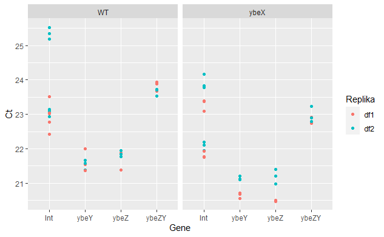

```r
ggplot(data = hexamers)+
  geom_point(mapping = aes(x=Gene, y=Ct, color=Replika))+
  facet_wrap(~ Bacteria)
```

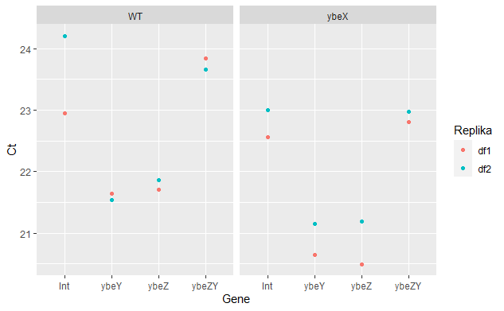

```r
ggplot(data = hexamers, aes(x = Gene, y = Ct, color =Replika)) +
  stat_summary(fun=mean, geom = "point")+
  facet_wrap(~Bacteria)
```

```r
mixprime <- mutate(mixprime, SamP = `Sample Name` )
mixprime <- rename(mixprime, Strain = `Sample Name` )

mixprime <- mixprime %>% mutate(Strain = case_when(
Strain == "C1" ~ "Lnt2_WT_df1", Strain == "D1" ~ "Lnt2_WT_df1",
Strain == "E1" ~ "Lnt2_WT_df1", Strain == "C7" ~ "Lnt2_WT_df2",
Strain == "D7" ~ "Lnt2_WT_df2", Strain == "E7" ~ "Lnt2_WT_df2",

Strain == "C2" ~ "Lnt_WT_df1", Strain == "D2" ~ "Lnt_WT_df1",
Strain == "E2" ~ "Lnt_WT_df1", Strain == "C8" ~ "Lnt_WT_df2",
Strain == "D8" ~ "Lnt_WT_df2", Strain == "E8" ~ "Lnt_WT_df2",

Strain == "C3" ~ "ybeY_WT_df1", Strain == "D3" ~ "ybeY_WT_df1",
Strain == "E3" ~ "ybeY_WT_df1", Strain == "C9" ~ "ybeY_WT_df2",
Strain == "D9" ~ "ybeY_WT_df2", Strain == "E9" ~ "ybeY_WT_df2",

Strain == "C4" ~ "ybeZ_WT_df1", Strain == "D4" ~ "ybeZ_WT_df1",
Strain == "E4" ~ "ybeZ_WT_df1", Strain == "C10" ~ "ybeZ_WT_df2",
Strain == "D10" ~ "ybeZ_WT_df2", Strain == "E10" ~ "ybeZ_WT_df2",

Strain == "C5" ~ "ybeZY_WT_df1", Strain == "D5" ~ "ybeZY_WT_df1",
Strain == "E5" ~ "ybeZY_WT_df1", Strain == "C11" ~ "ybeZY_WT_df2",
Strain == "D11" ~ "ybeZY_WT_df2", Strain == "E11" ~ "ybeZY_WT_df2",

Strain == "C13" ~ "Lnt2_X_df1", Strain == "D13" ~ "Lnt2_X_df1",
Strain == "E13" ~ "Lnt2_X_df1", Strain == "C19" ~ "Lnt2_X_df2",
Strain == "D19" ~ "Lnt2_X_df2", Strain == "E19" ~ "Lnt2_X_df2",

Strain == "C14" ~ "Lnt_X_df1", Strain == "D14" ~ "Lnt_X_df1",
Strain == "E14" ~ "Lnt_X_df1", Strain == "C20" ~ "Lnt_X_df2",
Strain == "D20" ~ "Lnt_X_df2", Strain == "E20" ~ "Lnt_X_df2",

Strain == "C15" ~ "ybeY_X_df1", Strain == "D15" ~ "ybeY_X_df1",
Strain == "E15" ~ "ybeY_X_df1", Strain == "C21" ~ "ybeY_X_df2",
Strain == "D21" ~ "ybeY_X_df2", Strain == "E21" ~ "ybeY_X_df2",

Strain == "C16" ~ "ybeZ_X_df1", Strain == "D16" ~ "ybeZ_X_df1",
Strain == "E16" ~ "ybeZ_X_df1", Strain == "C22" ~ "ybeZ_X_df2",
Strain == "D22" ~ "ybeZ_X_df2", Strain == "E22" ~ "ybeZ_X_df2",

Strain == "C17" ~ "ybeZY_X_df1", Strain == "D17" ~ "ybeZY_X_df1",
Strain == "E17" ~ "ybeZY_X_df1", Strain == "C23" ~ "ybeZY_X_df2",
Strain == "D23" ~ "ybeZY_X_df2", Strain == "E23" ~ "ybeZY_X_df2"
))
```

```r
mixprime <- mixprime %>% mutate( Gene = case_when(Strain %in% c("Lnt2_WT_df1", "Lnt2_WT_df2", "Lnt_WT_df1", "Lnt_WT_df2", "Lnt2_X_df1", "Lnt2_X_df2", "Lnt_X_df1", "Lnt_X_df2") ~ "lnt", Strain %in% c("ybeY_WT_df1", "ybeY_WT_df2", "ybeY_X_df1", "ybeY_X_df2") ~ "ybeY", Strain %in% c("ybeZ_WT_df1", "ybeZ_WT_df2", "ybeZ_X_df1", "ybeZ_X_df2") ~ "ybeZ", Strain %in% c("ybeZY_WT_df1", "ybeZY_WT_df2", "ybeZY_X_df1", "ybeZY_X_df2") ~ "ybeZY"
                   ),

Bacteria = case_when(Strain %in% c("Lnt2_WT_df1", "Lnt2_WT_df2", "Lnt_WT_df1", "Lnt_WT_df2", "ybeY_WT_df1", "ybeY_WT_df2","ybeZ_WT_df1", "ybeZ_WT_df2", "ybeZY_WT_df1", "ybeZY_WT_df2") ~ "WT",
                     Strain %in% c("Lnt2_X_df1", "Lnt2_X_df2", "Lnt_X_df1", "Lnt_X_df2", "ybeY_X_df1", "ybeY_X_df2","ybeZ_X_df1", "ybeZ_X_df2", "ybeZY_X_df1", "ybeZY_X_df2") ~ "ybeX"),

Replika = case_when(Strain %in% c("Lnt2_WT_df1", "Lnt_WT_df1", "ybeY_WT_df1", "ybeZ_WT_df1", "ybeZY_WT_df1",  "Lnt2_X_df1", "Lnt_X_df1", "ybeY_X_df1", "ybeZ_X_df1", "ybeZY_X_df1") ~ "df1",
                    Strain %in% c( "Lnt2_WT_df2", "Lnt_WT_df2", "ybeY_WT_df2", "ybeZ_WT_df2", "ybeZY_WT_df2", "Lnt2_X_df2", "Lnt_X_df2", "Lnt_X_df2", "ybeY_X_df2", "ybeY_X_df2", "ybeZ_X_df2", "ybeZY_X_df2") ~ "df2" ))

mixprime <- mutate(mixprime, Primer ="Mixprimer")
```

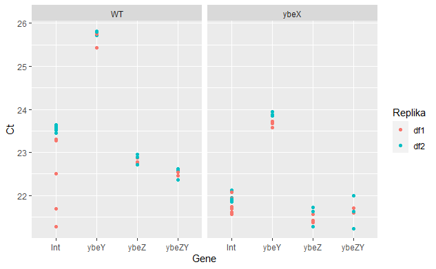

```r
ggplot(data = mixprime)+
  geom_point(mapping = aes(x=Gene, y=Ct, color=Replika))+
  facet_wrap(~ Bacteria)
```

```r
dfbound <- rbind(hexamers, mixprime)
```

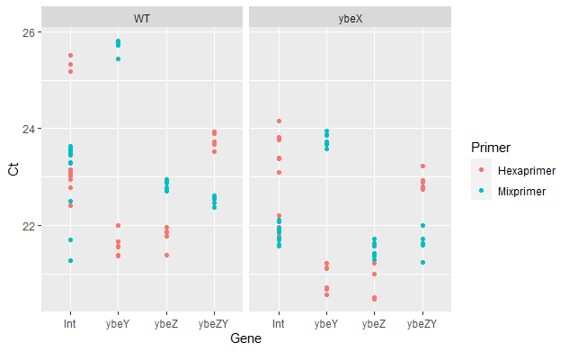

```r
ggplot(data = dfbound)+
  geom_point(mapping = aes(x=Gene, y=Ct, color=Primer))+
  facet_wrap(~Bacteria)
```

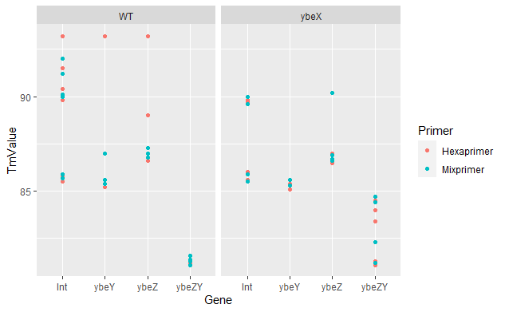

```r
ggplot(data = dfbound)+
  geom_point(mapping = aes(x=Gene, y=TmValue, color=Primer))+
  facet_wrap(~Bacteria)
```

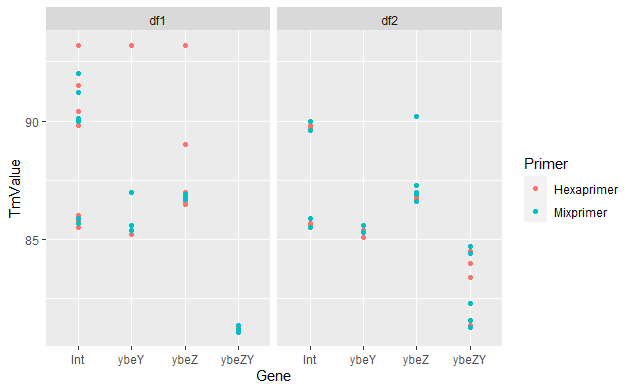

```r
ggplot(data = dfbound)+
  geom_point(mapping = aes(x=Gene, y=TmValue, color=Primer))+
  facet_wrap(~Replika)
```

```r
hexamers_summarised <- hexamers %>%
  group_by(Gene) %>%
  summarise(N = n())
hexamers_summarised
```

| Gene | N |
| --- | --- |
| lnt | 24 |
| ybeY | 12 |
| ybeZ | 12 |
| ybeZY | 12 |

```r
mixprime_summarised <- mixprime %>%
  group_by(Gene) %>%
  summarise(N = n())
mixprime_summarised
```

| Gene | N |
| --- | --- |
| lnt | 24 |
| ybeY | 12 |
| ybeZ | 12 |
| ybeZY | 12 |

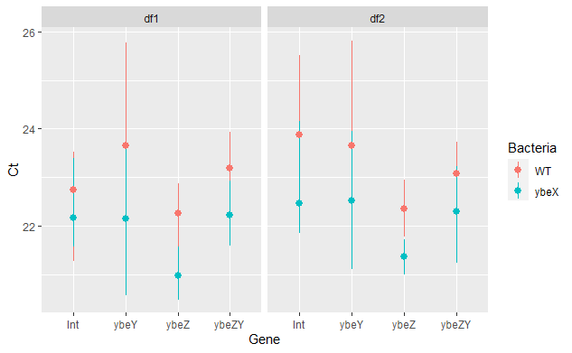

```r
ggplot(data = dfbound) +
  stat_summary(
    mapping = aes(x = Gene, y = Ct, color= Bacteria),
    fun.min = min,
    fun.max = max,
    fun = mean)+
  facet_wrap(~Replika)
```

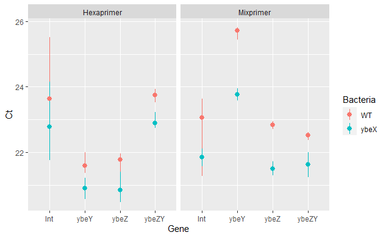

```r
ggplot(data = dfbound) +
  stat_summary(
    mapping = aes(x = Gene, y = Ct, color= Bacteria),
    fun.min = min,
    fun.max = max,
    fun = mean)+
  facet_wrap(~Primer)
```

```r
library(ggdist)
```

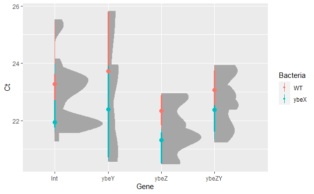

```r
ggplot(data = dfbound) +
  stat_halfeye(
    mapping = aes(x = Gene, y = Ct, color= Bacteria))
```